# CMM535 Coursework PART 2

SAMUEL ONEKUTU 2114194, School of Computing, Robert Gordon University Aberdeen

4/20/2022

## Modeling, Experiments, Evaluation and Deployment

~~~~~~~~~~~~~~~~~~~~~~~~~~~~~~~~~~~~~~~~~~~~~~~~~~~~~~~~~~~~~~~~~~~~~~~~~~~~~~~~~~~

##### Importing neccessary libraries

```r
library(ggplot2)  # for generating plots
library(corrplot) # plot Correlogram
library(caret)    # wrapping library for training and testing
library(randomForest)# to loading Random Forest classifier
library(leaps)    # for "forward" "backward" and "mixed" feature selection
library(MASS)     # for Feature Transformation
```

##### Importing CSV Files

Importing the data set and creating a copy from the original

```r
escapesClean = read.csv("escapesClean.csv",stringsAsFactors = T)
escapes <- escapesClean  # creating copy
summary(escapesClean)
```

```
##     Season           Species         Age        Average.Weight     Number
##  Autumn:57   Other       : 55   Min.   : 2.00   Min.   :  15   Min.   :     1
##  Spring:58   Salmon      :151   1st Qu.:10.00   1st Qu.: 600   1st Qu.:   216
##  Summer:51   Salmon.Brood:  2   Median :15.00   Median :2000   Median :  3000
##  Winter:55   Salmon.Fresh: 13   Mean   :15.31   Mean   :2191   Mean   : 13536
##                                 3rd Qu.:19.00   3rd Qu.:3400   3rd Qu.: 10775
##                                 Max.   :48.00   Max.   :9250   Max.   :336470
##      Cause     Producing      SLR                Cu                Zn
##  Human  :138   No : 21   Min.   :-0.7633   Min.   :-3.9100   Min.   :-0.4252
##  Natural: 83   Yes:200   1st Qu.: 0.6599   1st Qu.: 0.5429   1st Qu.: 6.8072
##                          Median : 2.2654   Median : 1.7553   Median : 9.5058
##                          Mean   : 3.1627   Mean   : 2.1218   Mean   :10.1518
##                          3rd Qu.: 3.1242   3rd Qu.: 3.6470   3rd Qu.:13.8066
##                          Max.   :35.2477   Max.   : 8.4502   Max.   :24.7346
##        N                P               Org
##  Min.   :-105.5   Min.   :-13.97   Min.   :  65.13
##  1st Qu.: 240.9   1st Qu.: 80.49   1st Qu.: 356.62
##  Median : 358.3   Median :121.98   Median : 564.55
##  Mean   : 340.0   Mean   :122.59   Mean   : 553.28
##  3rd Qu.: 437.0   3rd Qu.:162.52   3rd Qu.: 726.65
##  Max.   : 696.5   Max.   :244.29   Max.   :1092.56
```

##### Feature Evalution and Selection

I will began by evaluating the Distribution of some Numeric features and then proceed to selecting the best features against Targets; **Number** and **Cause**.

**Basic Observations**

1. “Season” has 4 category levels
2. “Species” has Salmon as the modal class
3. “Age” is numerical
4. “cause” imbalance two classes
5. “producing” two classes too

**Distribution Observations**

I would start by analysis the distribution of the target Variable **Number**.

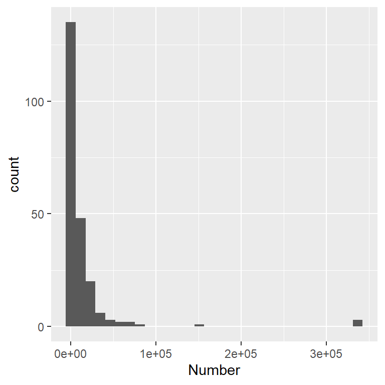

```r
ggplot(data= escapes, aes(x=Number)) + geom_histogram()
```

```r
shapiro.test(escapes$Number)
```

```
##
##  Shapiro-Wilk normality test
##
## data:  escapes$Number
## W = 0.29808, p-value < 2.2e-16
```

seeing that the target is skewed it can be expected that some of the predictors/features too will be skewed

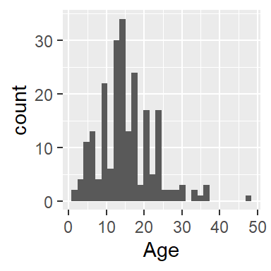

```r
ggplot(data= escapes, aes(x=Age)) + geom_histogram()
```

```r
shapiro.test(escapes$Age)
```

```
##
##  Shapiro-Wilk normality test
##
## data:  escapes$Age
## W = 0.95642, p-value = 2.945e-06
```

the Age is not normal 4. “Average.weight”

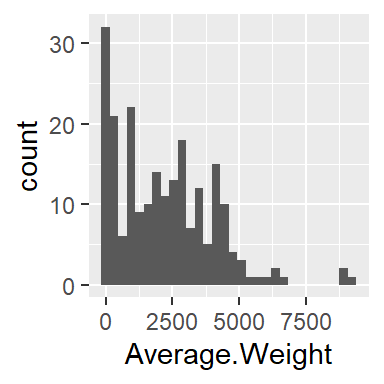

```r
ggplot(data= escapes, aes(x=Average.Weight)) + geom_histogram()
```

```r
shapiro.test(escapes$Average.Weight)
```

```
##
##  Shapiro-Wilk normality test
##
## data:  escapes$Average.Weight
## W = 0.91533, p-value = 6.548e-10
```

**Test of other numeric variables**

```r
#ggplot(data= escapes, aes(x=Org)) + geom_histogram()
shapiro.test(escapes$Org)
```

```
##
##  Shapiro-Wilk normality test
##
## data:  escapes$Org
## W = 0.98431, p-value = 0.01506
```

```r
shapiro.test(escapes$SLR)
```

```
##
##  Shapiro-Wilk normality test
##
## data:  escapes$SLR
## W = 0.54039, p-value < 2.2e-16
```

```r
shapiro.test(escapes$Zn)
```

```
##
##  Shapiro-Wilk normality test
##
## data:  escapes$Zn
## W = 0.98671, p-value = 0.03721
```

```r
shapiro.test(escapes$Cu)
```

```
##
##  Shapiro-Wilk normality test
##
## data:  escapes$Cu
## W = 0.96588, p-value = 3.674e-05
```

```r
shapiro.test(escapes$P)
```

```
##
##  Shapiro-Wilk normality test
##
## data:  escapes$P
## W = 0.9868, p-value = 0.03855
```

```r
shapiro.test(escapes$N)
```

```
##
##  Shapiro-Wilk normality test
##
## data:  escapes$N
## W = 0.99008, p-value = 0.1339
```

Though Nitrogen “N” is normal with p-value = 0.1339, all other features(“SLR”,“Zn”,“Cu”,“P”and “Org”) have abnormal or skewed distributions and generally no major outlier Values the target ‘Number’ is also not normally distributed

##### Looking at all the features together and Selections

I will begin by examining the correlation of the features with each variable against target(**Number**) and with each other in the Correlation plot below.

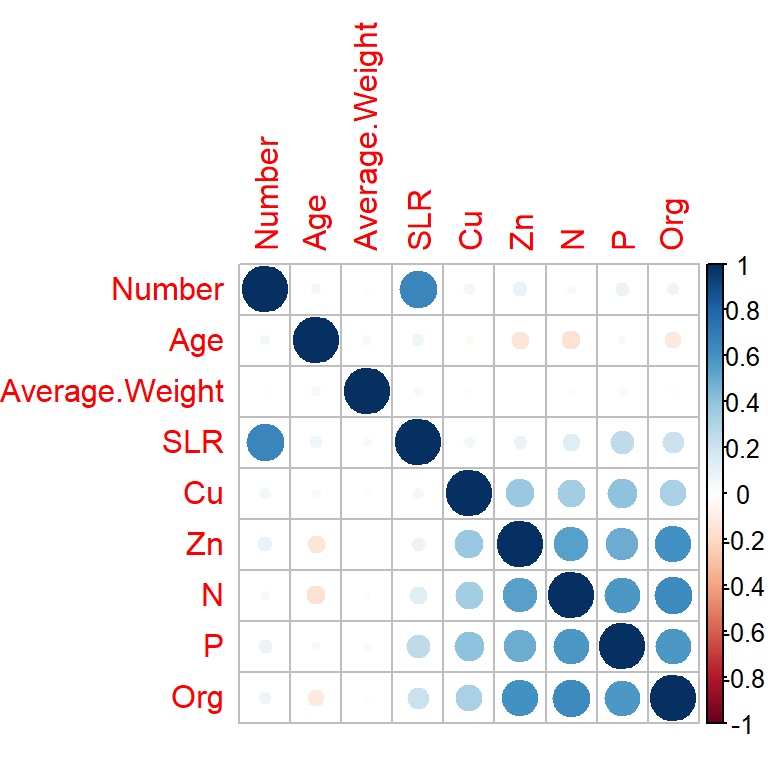

```r
corr= cor(escapes[c(5,3,4,8,9,10,11,12,13)])   # manually selected numerical variable
corrplot(corr)
```

correlation plot

##### Changing Categorical Varables to Numerics

creating copy of one-hot encoded dataframe in order to utilize categorical features (though this is automatically handle but for simplifying model and visualization)

```r
escapes1 <- escapes  # copy
escapes1$Cause <- as.numeric(escapes1$Cause)-1  #binary class conversion 0== Human and 1==Natural
escapes1$Producing <- abs(as.numeric(escapes1$Producing)-2) #binary class conversion 1== Yes and 0==No
dummy<- dummyVars("~.",data=escapes1)  # creating dummy variable

# Creating New copy with Dummyvariables R for Visualization purposes also
escapesD <- data.frame(predict(dummy, newdata = escapes1))
```

**‘Cause’ to Numeric** note: for Causes 0== Human and 1==Natural. also for Producing 1== Yes and 0==No another correlation plot with categorical variables

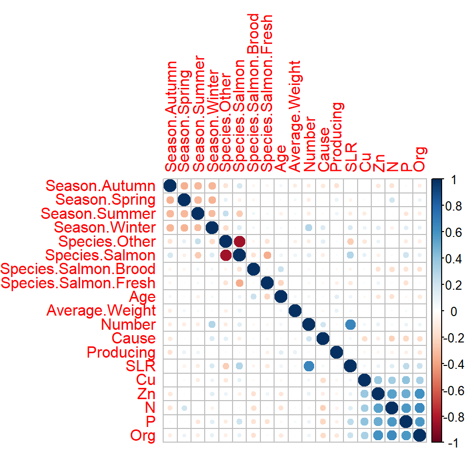

```r
corr= cor(escapesD)   # selecting numerical variable
corrplot(corr)
```

correlation plot

##### Feature selection using Leaps package

SLR appears to be a very good predictor having a good correlation with Number but a little correlated with the other predictors.

i will be trying the Exhaustive search only because our variables are not too many.

```r
fullSearch = regsubsets(Number ~ .,data = escapesD,method = "exhaustive", nvmax = 12)   # 12predictors
```

```
## Reordering variables and trying again:
```

```r
full = summary(fullSearch)
```

Adjusted R-squared by “number of variable”

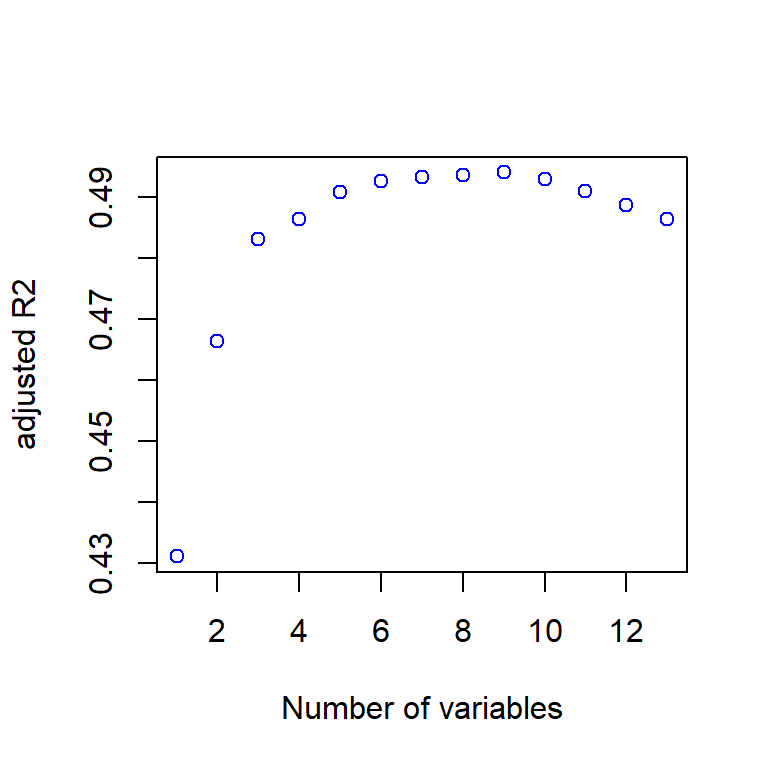

```r
plot(full$adjr2, ylab = "adjusted R2", xlab = "Number of variables",col = "blue")
```

Feature selection Number

The variable appear to plateau at about 6 Variables at the elbow, i will select top 6 also because of my Shiny App specifications.

below are the six relevant features

```r
top6=full$which[6,-c(1)] # selected variables at top 6(role6) excluding intercept
numberTop6 = names(top6)[top6]
numberTop6
```

```
## [1] "Season.Winter" "Cause"         "SLR"           "Zn"
## [5] "P"             "Org"
```

**features for selection for ‘Cause’ Classifications also**

```r
# features for 'Cause'
fullSearch = regsubsets(Cause ~ .,data = escapesD,method = "exhaustive", nvmax = 12)   # 12predictors
```

```
## Reordering variables and trying again:
```

```r
full = summary(fullSearch)
top6=full$which[6,-c(1)] # selected variables at top 5(role5) excluding intercept
causeTop6 = names(top6)[top6]
causeTop6
```

```
## [1] "Season.Winter" "Species.Other" "Number"        "Cu"
## [5] "N"             "P"
```

```r
escapesD$Cause <- as.factor(escapesD$Cause)  #now converting back to factors so i can use feature in confusion matrix
```

##### Spliting Data

Finally splitting data: for best data science practise and evaluation.

```r
set.seed(101)
selected= createDataPartition(escapesD$Cause,p=0.7,list = F) # selected is a boolean of rows selected
escapesTrain= escapesD[selected,]
escapesTest = escapesD[-selected,]
dim(escapesD)
```

```
## [1] 221  19
```

```r
dim(escapesTrain)
```

```
## [1] 156  19
```

```r
dim(escapesTest)
```

```
## [1] 65 19
```

### EXPERMENTS

#### 1. CLASSIFICATION

##### Model1 Logistic Regression

**The Model Selection and Turning Justification**

1. best performance was seen using selected features in earlier feature selection section above.
2. There was no need to change the threshold from 0.5 because best accuracy was achieved at 0.5

Modeling using Caret package

```r
# using Caret to train and test
model1 <- train(Cause~Season.Winter+Species.Other+Number+Cu+N+P,data=escapesTrain,method = "glm",family = "binomial")
```

**The Model1 Evaluation**

```r
probs = predict(model1, escapesTest, type = "raw")   # the models way of viewing the data with probability
#predictedmodel1 = as.factor(ifelse(probs$`1`<0.5,0,1)) # a col assigning below 0.5 as Human
confusionMatrix(probs,as.factor(as.numeric(escapesTest$Cause)-1),mode="everything",positive ="0")
```

```
## Confusion Matrix and Statistics
##
##           Reference
## Prediction  0  1
##          0 39 16
##          1  2  8
##
##                Accuracy : 0.7231
##                  95% CI : (0.5981, 0.8269)
##     No Information Rate : 0.6308
##     P-Value [Acc > NIR] : 0.076717
##
##                   Kappa : 0.3237
##
##  Mcnemar's Test P-Value : 0.002183
##
##             Sensitivity : 0.9512
##             Specificity : 0.3333
##          Pos Pred Value : 0.7091
##          Neg Pred Value : 0.8000
##               Precision : 0.7091
##                  Recall : 0.9512
##                      F1 : 0.8125
##              Prevalence : 0.6308
##          Detection Rate : 0.6000
##    Detection Prevalence : 0.8462
##       Balanced Accuracy : 0.6423
##
##        'Positive' Class : 0
##
```

##### Model2 Random Forest

**The Model Selection and Turning Justification**

```r
trcont_oob <- trainControl(method = "oob")   # bootstrap's out of bag for recommended for Random  forest
```

```r
set.seed(101)
model2 <- train(Cause~., data=escapesTrain,method="rf", trControl = trcont_oob,maxnodes=20,ntree=250,tuneGrid = expand.grid(mtry=c(3:9)))
# got better performance by using the top5 variables rather than using all
print(model2)
```

```
## Random Forest
##
## 156 samples
##  18 predictor
##   2 classes: '0', '1'
##
## No pre-processing
## Resampling results across tuning parameters:
##
##   mtry  Accuracy   Kappa
##   3     0.6474359  0.1825457
##   4     0.6923077  0.3042185
##   5     0.6987179  0.3162999
##   6     0.6538462  0.2060320
##   7     0.6923077  0.3042185
##   8     0.6474359  0.2055556
##   9     0.6794872  0.2853216
##
## Accuracy was used to select the optimal model using the largest value.
## The final value used for the model was mtry = 5.
```

```r
varImp(model2)
```

```
## rf variable importance
##
##                      Overall
## Number               100.000
## Org                   74.855
## Age                   68.076
## Cu                    59.716
## N                     56.968
## SLR                   53.825
## Zn                    52.405
## P                     50.346
## Average.Weight        47.496
## Season.Winter          7.509
## Season.Summer          7.049
## Season.Autumn          6.997
## Producing              6.972
## Species.Other          6.900
## Season.Spring          5.922
## Species.Salmon         5.599
## Species.Salmon.Fresh   1.367
## Species.Salmon.Brood   0.000
```

**The Model2 Evaluation**

```r
pred = predict(model2,escapesTest)
confusionMatrix(pred,as.factor(as.numeric(escapesTest$Cause)-1), mode= "everything",positive = "0")
```

```
## Confusion Matrix and Statistics
##
##           Reference
## Prediction  0  1
##          0 41 20
##          1  0  4
##
##                Accuracy : 0.6923
##                  95% CI : (0.5655, 0.8009)
##     No Information Rate : 0.6308
##     P-Value [Acc > NIR] : 0.1848
##
##                   Kappa : 0.2015
##
##  Mcnemar's Test P-Value : 2.152e-05
##
##             Sensitivity : 1.0000
##             Specificity : 0.1667
##          Pos Pred Value : 0.6721
##          Neg Pred Value : 1.0000
##               Precision : 0.6721
##                  Recall : 1.0000
##                      F1 : 0.8039
##              Prevalence : 0.6308
##          Detection Rate : 0.6308
##    Detection Prevalence : 0.9385
##       Balanced Accuracy : 0.5833
##
##        'Positive' Class : 0
##
```

```r
paste('number difference in two models predictions is: ',sum(!(pred==probs)))
```

```
## [1] "number difference in two models predictions is:  8"
```

##### Experiment 1 Discussion

- The two models coincidentally performed the similarly generally (notice the F1 scores) though they predicted 8 instances differently
- Interestingly the performance of model1 did reduced when I used the variables selected by by model2 the random forest.
- Finally though Model2(Random Forest) is More flexible for more additional features but I would recommend Model1(Logistic Regression) more because it is less computationally demanding and Model1 performed a little better than model2 in this case.

#### 2. REGRESSION

##### Model3 Linear Regression

*The Model Selection and Turning Justification*

**the Transformation of the training set with BoxCox**

```r
bc = boxcox(lm(escapesTrain$Number~1))  # the target Number against a constant
```

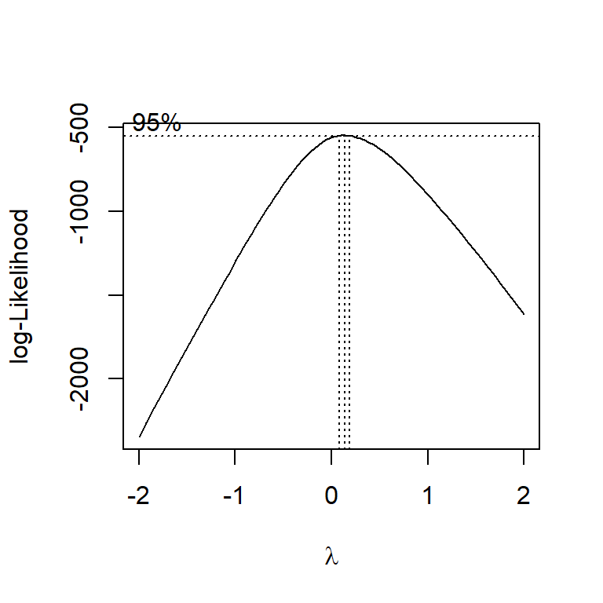

```r
# we can estimate the power q is about 0.2 from the plot below but I will get the exact value with lines below

q = bc$x[which.max(bc$y)]
paste("the value actually is ",q)
```

```
## [1] "the value actually is  0.141414141414141"
```

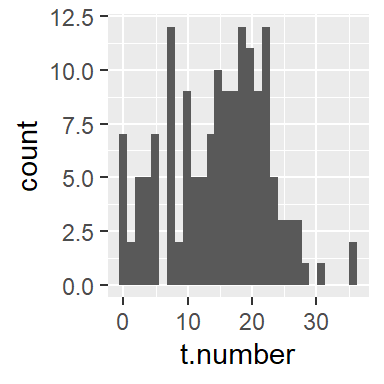

```r
TescapesTrain <- escapesTrain # creating New Trainset copy to append transformed Features
TescapesTrain$t.number = (TescapesTrain$Number^q - 1)/q #saving transformed Target to the dataframe
ggplot(data= TescapesTrain, aes(x=t.number)) + geom_histogram()
```

```r
# function to reverse transformation
reverseTrans = function(z){ return ( (q*z + 1)^(1/q)  )}
```

“Season.Winter” “Cause” “SLR” “Zn” “P” “Org”

```r
model3 = lm(Number~Season.Winter+Cause+SLR+Zn+P+Org,data = escapesTrain)
#summary(model3)
```

**The Model3 Evaluation**

```r
pred = predict(model3, escapesTest)
postResample(pred, escapesTest$Number)
```

```
##         RMSE     Rsquared          MAE
## 2.856575e+04 5.668025e-01 1.698239e+04
```

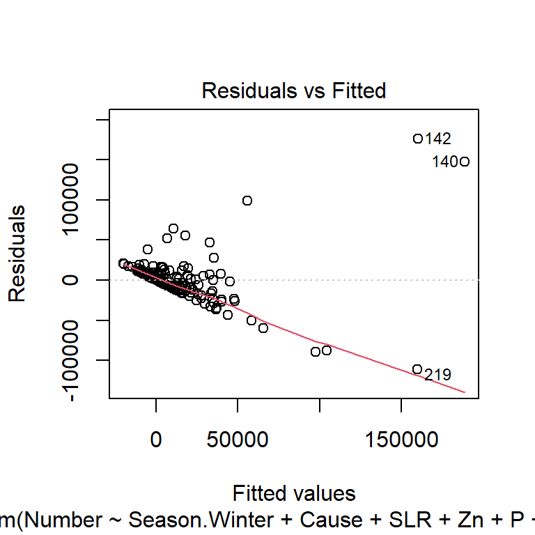

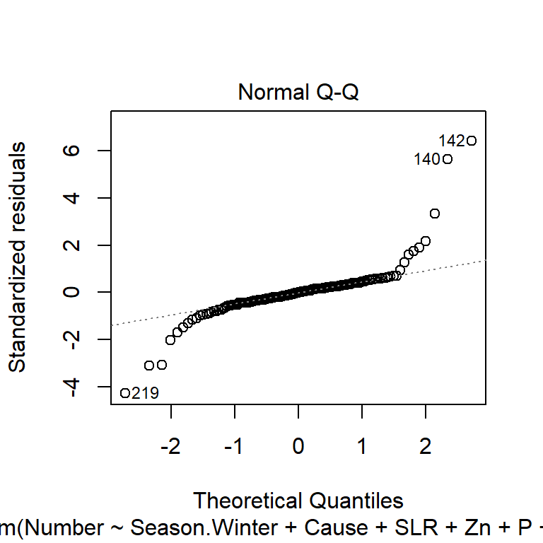

```r
# examine the residuals
plot(model3, which = c(1,2))
```

the *residual plots* shows the linear Regression Model is still not adequate as a Pattern is seen and the QQ plot too

##### Model4 Regression with Random Forest

Can the random forest for Regression model over come the challenge of distributions not being normal and can performance also improve.

*The Model Selection and Turning Justification*

```r
set.seed(123)
prep = c("range","pca")
model4 <- train(Number~Season.Winter+Cause+SLR+Zn+P+Org,data = escapesTrain,method = "rf",metric = "RMSE",trControl = trcont_oob) #The number of features in the candidate set at each node (mtry)
print(model4)
```

```
## Random Forest
##
## 156 samples
##   6 predictor
##
## No pre-processing
## Resampling results across tuning parameters:
##
##   mtry  RMSE      Rsquared
##   2     32275.33  0.3886895
##   4     33931.95  0.3243248
##   6     38774.71  0.1176973
##
## RMSE was used to select the optimal model using the smallest value.
## The final value used for the model was mtry = 2.
```

*The Model4 Evaluation*

```r
pred = predict(model4, escapesTest)
postResample(pred, escapesTest$Number)
```

```
##         RMSE     Rsquared          MAE
## 2.402304e+04 7.041971e-01 1.342602e+04
```

```r
varImp(model4)
```

```
## rf variable importance
##
##               Overall
## SLR           100.000
## Org            14.948
## Zn             13.458
## P              12.748
## Season.Winter   8.498
## Cause1          0.000
```

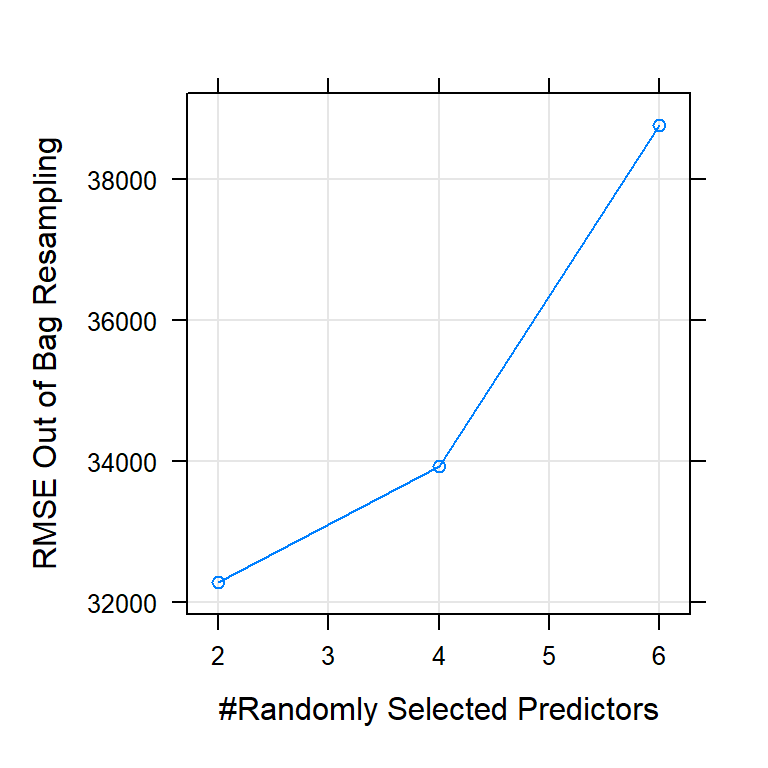

```r
# examine the residuals
plot(model4, which = c(1,2))
```

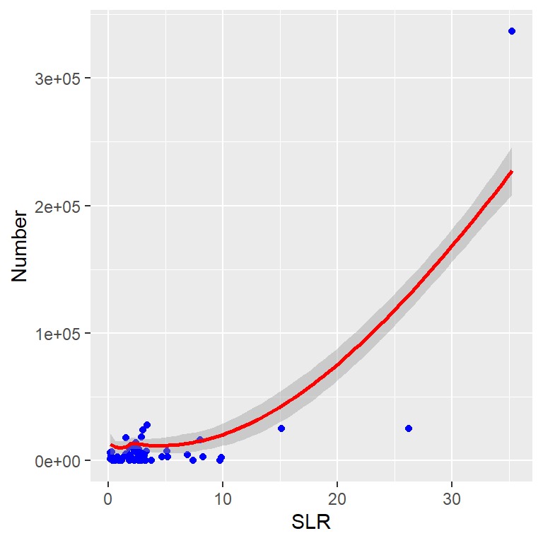

```r
escapesTest$pred <- pred
ggplot() + geom_point(data=escapesTest, aes(x=SLR,y=Number),color='blue') + geom_smooth(data=escapesTest, aes(x=SLR,y=pred),color='red')
```

model4 is the red line

##### Experiment 2 Discussion

- Model4(Random Forest for Regression) performed better than Model3 (the standard linear Regression model)
- feature ‘SLR’ features seems like the most important numerical variable.
- A form of multi-polynomial Model may fit better as seen above

#### 3. MODEL DEPLOYMENT

As recommended from experiment1; I would be selecting the Logistic regression Model1 and saving it to an rds file

```r
saveRDS(model1,"model.rds")
```

In the attached shiny app, I will continue the deployment.